# 비교 분석: 무엇이 다를까?

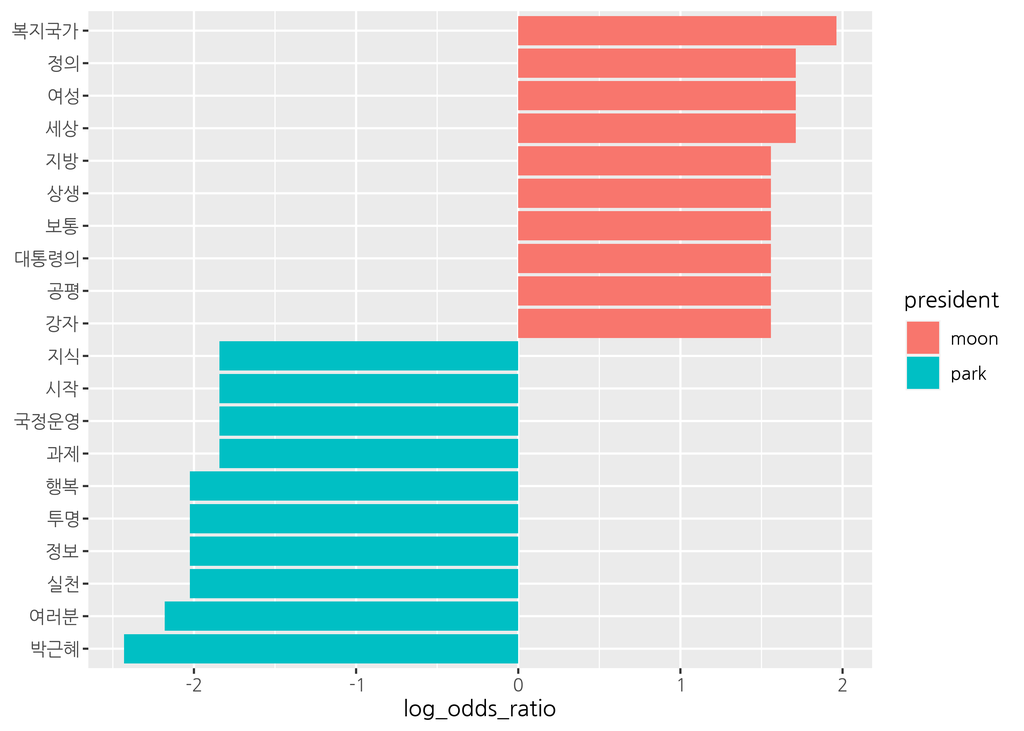

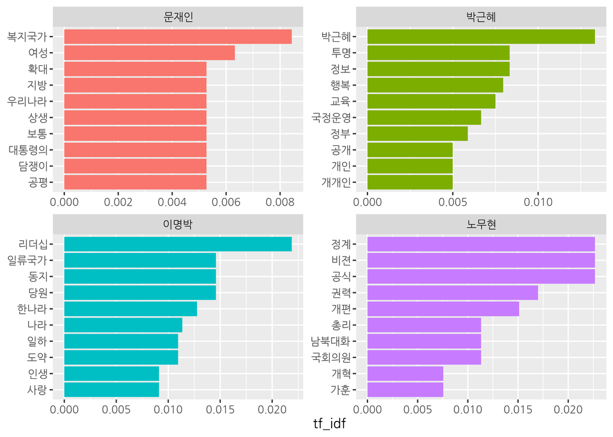

### 비교 분석

- 여러 텍스트를 비교해 차이를 알아보는 분석 방법
- 단어 빈도 분석을 응용해 자주 사용된 단어의 차이를 살펴봄

### 텍스트 합치기

- 텍스트를 비교하기 위해 여러 개의 텍스트를 하나의 데이터셋으로 합치는 작업

##### 데이터 불러오기

- 문재인 대통령과 박근혜 전 대통령의 대선 출마 선언문 불러오기
- tibble 구조로 변환하고 연설문 구분 위해 대통령 이름 부여

```r
library(dplyr)

# 문재인 대통령 연설문 불러오기
raw_moon <- readLines("speech_moon.txt", encoding = "UTF-8")
moon <- raw_moon %>%
  as_tibble() %>%
  mutate(president = "moon")

# 박근혜 대통령 연설문 불러오기
raw_park <- readLines("speech_park.txt", encoding = "UTF-8")
park <- raw_park %>%
  as_tibble() %>%
  mutate(president = "park")
```

##### 데이터 합치기

- 두 데이터를 행(세로) 방향으로 결합
- 출력 결과 보기 편하게 `select()`로 변수 순서 바꾸기
- 윗부분은 문재인 대통령, 아랫부분은 박근혜 전 대통령 연설문

```r
bind_speeches <- bind_rows(moon, park) %>%
  select(president, value)
```

```r
head(bind_speeches)
```

```
## # A tibble: 6 x 2
##   president value
##   <chr>     <chr>
## 1 moon      "정권교체 하~
## 2 moon      "  정치교체 ~
## 3 moon      "  시대교체 ~
## 4 moon      "  "
## 5 moon      "  ‘불비불~
## 6 moon      ""
```

```r
tail(bind_speeches)
```

```
## # A tibble: 6 x 2
##   president value
##   <chr>     <chr>
## 1 park      "국민들이 꿈~
## 2 park      ""
## 3 park      "감사합니다."
## 4 park      ""
## 5 park      "2012년 7월 ~
## 6 park      "새누리당 예~
```

박근혜 전 대통령의 대선 출마 선언문 출처: bit.ly/easytext_31

#### 집단별 단어 빈도 구하기

##### 1. 기본적인 전처리 및 토큰화

- 한글 이외의 문자, 연속된 공백 제거
- `bind_speeches`는 tibble 구조이므로 `mutate()` 활용

```r
# 기본적인 전처리
library(stringr)
speeches <- bind_speeches %>%
  mutate(value = str_replace_all(value, "[^가-힣]", " "),
         value = str_squish(value))

speeches
```

```
## # A tibble: 213 x 2
##    president value
##    <chr>     <chr>
##  1 moon      "정권교체 하겠습니다"
##  2 moon      "정치교체 하겠습니다"
##  3 moon      "시대교체 하겠습니다"
##  4 moon      ""
##  5 moon      "불비불명 이라는 고사가 있습니다 남~
##  6 moon      ""
##  7 moon      "그 동안 정치와 거리를 둬 왔습니다 ~
##  8 moon      ""
##  9 moon      ""
## 10 moon      "우리나라 대통령 이 되겠습니다"
## # ... with 203 more rows
```

- 형태소 분석기를 이용해 명사 기준 토큰화

```r
# 토큰화
library(tidytext)
library(KoNLP)

speeches <- speeches %>%
  unnest_tokens(input = value,
                output = word,
                token = extractNoun)

speeches
```

```
## # A tibble: 3,001 x 2
##    president word
##    <chr>     <chr>
##  1 moon      "정권교체"
##  2 moon      "하겠습니"
##  3 moon      "정치"
##  4 moon      "교체"
##  5 moon      "하겠습니"
##  6 moon      "시대"
##  7 moon      "교체"
##  8 moon      "하겠습니"
##  9 moon      ""
## 10 moon      "불비불명"
## # ... with 2,991 more rows
```

#### 하위 집단별 단어 빈도 구하기 - `count()`

- `"moon"`과 `"park"`의 단어 빈도 각각 구하기

##### 샘플 텍스트로 작동 원리 알아보기

- `count()`에 집단을 구성하는 두 변수를 순서대로 입력

```r
df <- tibble(class = c("a", "a", "a", "b", "b", "b"),
             sex = c("female", "male", "female", "male", "male", "female"))
```

```r
df %>% count(class, sex)
```

```
## # A tibble: 4 x 3
##   class sex        n
##   <chr> <chr>  <int>
## 1 a     female     2
## 2 a     male       1
## 3 b     female     1
## 4 b     male       2
```

##### 두 연설문의 단어 빈도 구하기

```r
frequency <- speeches %>%
  count(president, word) %>%   # 연설문 및 단어별 빈도
  filter(str_count(word) > 1)  # 두 글자 이상 추출

head(frequency)
```

```
## # A tibble: 6 x 3
##   president word         n
##   <chr>     <chr>    <int>
## 1 moon      가능성       1
## 2 moon      가동         1
## 3 moon      가사         1
## 4 moon      가슴         2
## 5 moon      가족         1
## 6 moon      가족구조     1
```

`count()`는 입력한 변수의 알파벳, 가나다순으로 행을 정렬함

#### 자주 사용된 단어 추출하기

- `dplyr::slice_max()`: 값이 큰 상위 n개의 행을 추출해 내림차순 정렬

  `slice_min()`: 값이 작은 하위 n개 추출

#### 연설문에 가장 많이 사용된 단어 추출하기

- `president`별 고빈도 단어 상위 10개 추출

```r
top10 <- frequency %>%
  group_by(president) %>%  # president별로 분리
  slice_max(n, n = 10)     # 상위 10개 추출

top10
```

```
## # A tibble: 23 x 3
## # Groups:   president [2]
##    president word       n
##    <chr>     <chr>  <int>
##  1 moon      국민      21
##  2 moon      일자리    21
##  3 moon      나라      18
##  4 moon      우리      17
##  5 moon      경제      15
##  6 moon      사회      15
##  7 moon      대통령    12
##  8 moon      성장      12
##  9 moon      대한      11
## 10 moon      민국      11
## # ... with 13 more rows
```

#### 단어 빈도 동점 처리

```r
top10 %>%
  filter(president == "park")
```

```
## # A tibble: 11 x 3
## # Groups:   president [1]
##    president word       n
##    <chr>     <chr>  <int>
##  1 park      국민      71
##  2 park      행복      23
##  3 park      여러분    20
##  4 park      정부      17
##  5 park      경제      15
##  6 park      신뢰      11
##  7 park      국가      10
##  8 park      우리      10
##  9 park      사람       9
## 10 park      사회       9
## 11 park      일자리     9
```

#### 빈도 동점 단어 제외하고 추출하기

- `slice_max(with_ties = F)`: 원본 데이터의 정렬 순서에 따라 행 추출

```r
top10 <- frequency %>%
  group_by(president) %>%
  slice_max(n, n = 10, with_ties = F)

top10
```

```
## # A tibble: 20 x 3
## # Groups:   president [2]
##    president word       n
##    <chr>     <chr>  <int>
##  1 moon      국민      21
##  2 moon      일자리    21
##  3 moon      나라      18
##  4 moon      우리      17
##  5 moon      경제      15
##  6 moon      사회      15
##  7 moon      대통령    12
##  8 moon      성장      12
##  9 moon      대한      11
## 10 moon      민국      11
## 11 park      국민      71
## 12 park      행복      23
## 13 park      여러분    20
## 14 park      정부      17
## 15 park      경제      15
## 16 park      신뢰      11
## 17 park      국가      10
## 18 park      우리      10
## 19 park      사람       9
## 20 park      사회       9
```

#### 막대 그래프 만들기

##### 1. 변수의 항목별로 그래프만들기 - `facet_wrap()`

- `~` 뒤에 그래프를 나누는 기준 변수 입력

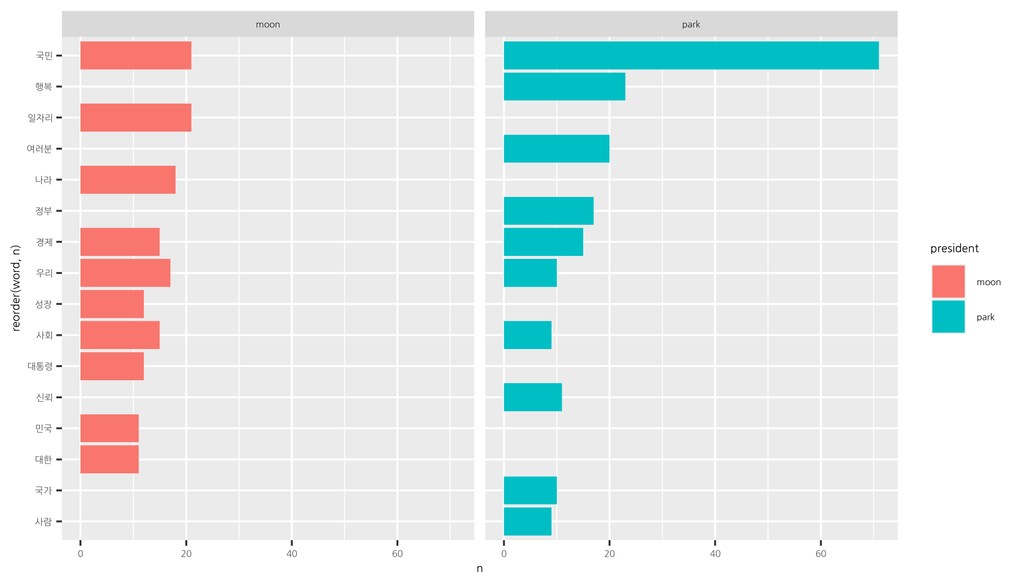

```r
library(ggplot2)
ggplot(top10, aes(x = reorder(word, n),
                  y = n,
                  fill = president)) +
  geom_col() +
  coord_flip() +
  facet_wrap(~ president)
```

##### 2. 그래프별 y축 설정하기

- 축을 구성하는 단어가 한 범주에만 있으면 축은 있지만 막대는 없는 항목 생김
  - ex) `"행복"`, `"나라"`

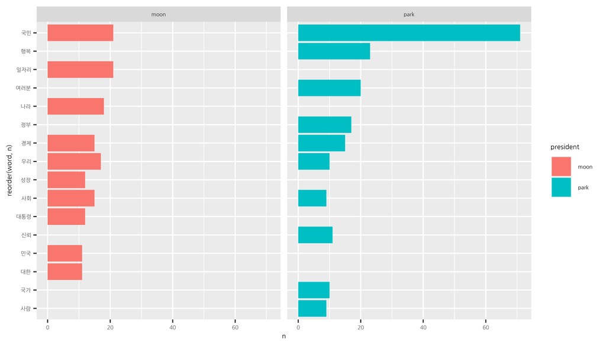

##### 2. 그래프별 y축 설정하기

- 축을 구성하는 단어가 한 범주에만 있으면 축은 있지만 막대는 없는 항목 생김
  - ex) `"행복"`, `"나라"`
- `scales`: 그래프의 축 통일 또는 각각 생성 결정
  - `"fixed"`: 축 통일(기본값)
  - `"free_y"`: 범주별로 y축 만듦

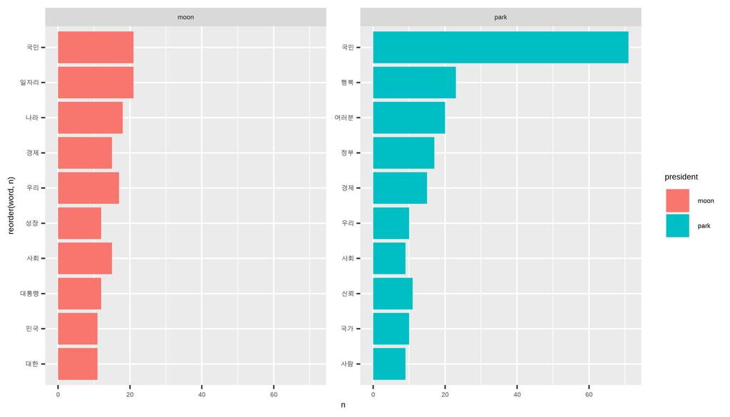

```r
ggplot(top10, aes(x = reorder(word, n),
                  y = n,
                  fill = president)) +
  geom_col() +
  coord_flip() +
  facet_wrap(~ president,         # president별 그래프 생성
              scales = "free_y")  # y축 통일하지 않음 #<<
```

#### 3. 특정 단어 제외하고 막대 그래프 만들기

- 박근혜 전 대통령 `"국민"` 빈도 너무 높아 다른 단어들 차이 드러나지 않음
- 전반적인 단어 빈도가 잘 드러나도록 제거

```r
top10 <- frequency %>%
  filter(word != "국민") %>%
  group_by(president) %>%
  slice_max(n, n = 10, with_ties = F)
```

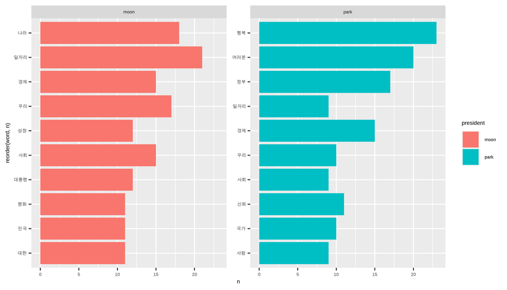

```r
ggplot(top10, aes(x = reorder(word, n),
                  y = n,
                  fill = president)) +
  geom_col() +
  coord_flip() +
  facet_wrap(~ president, scales = "free_y")
```

#### 4. 축 정렬하기

- x축을 지정할 때 `reorder()`를 사용했는데도 막대가 빈도 기준으로 완벽하게 정렬되지 않음
- 전체 빈도 기준으로 각 범주의 x축 순서를 정했기 때문

##### 그래프별로 축 정렬하기

- `tidytext::reorder_within()`: 변수의 항목별로 축 순서 따로 구하기
  - `x` : 축
  - `by` :정렬 기준
  - `within` : 그래프를 나누는 기준

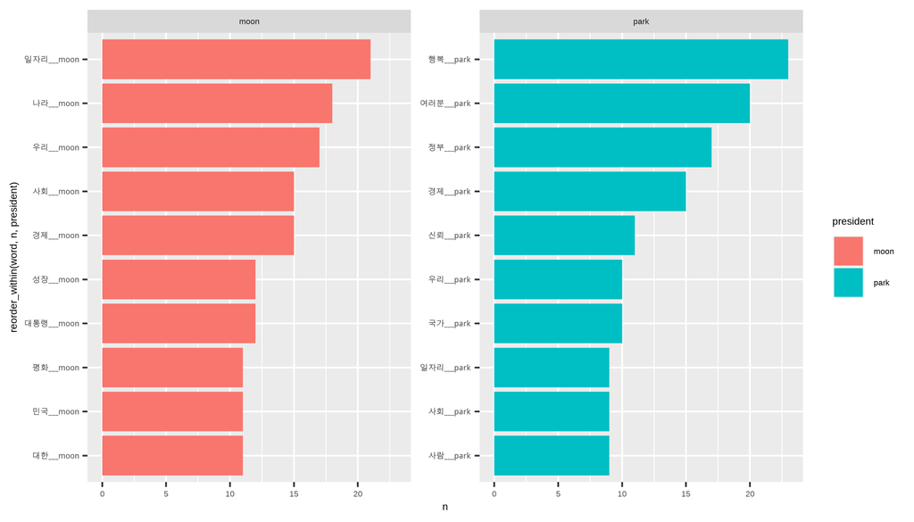

```r
ggplot(top10, aes(x = reorder_within(word, n, president),
                  y = n,
                  fill = president)) +
  geom_col() +
  coord_flip() +
  facet_wrap(~ president, scales = "free_y")
```

#### 5. 변수 항목 제거하기

- `tidytext::scale_x_reordered()`: 각 단어 뒤의 범주 항목 제거

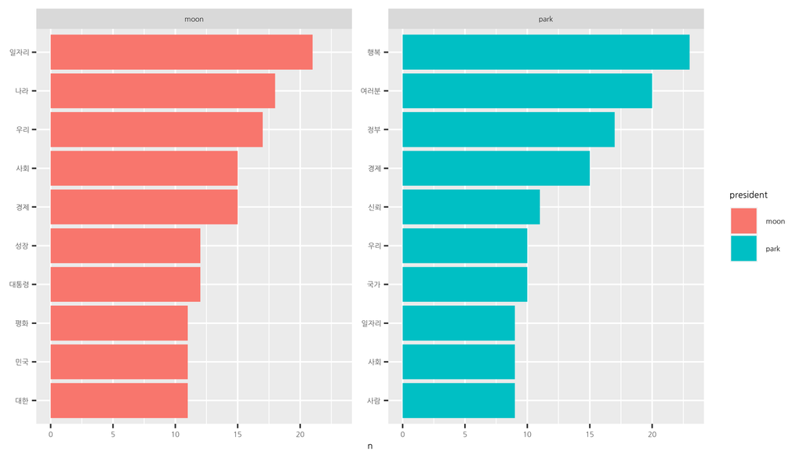

```r
ggplot(top10, aes(x = reorder_within(word, n, president),
                  y = n,
                  fill = president)) +
  geom_col() +
  coord_flip() +
  facet_wrap(~ president, scales = "free_y") +
  scale_x_reordered() + #<<
  labs(x = NULL) +                                    # x축 삭제
  theme(text = element_text(family = "nanumgothic"))  # 폰트
```

## 상대적으로 중요한 단어 비교하기

- 빈도 높은 단어를 비교하면
  - 어떤 텍스트든 일반적인 단어 빈도 높아 텍스트 차이 잘 드러나지 않음
    - ex) 연설문: `"우리"`, `"사회"`, `"경제"`, `"일자리"`
- 텍스트의 차이를 알아보려면
  - 특정 텍스트에는 많이 사용되었지만 다른 텍스트에는 적게 사용된 단어를 살펴봐야함

#### Long form을 Wide form으로 변환하기

- 여러 텍스트 비교하기 편하게 데이터 구조 바꾸기

##### Long form 데이터 살펴보기

- `frequency`: `president`가 `"moon"`인 행과 `"park"`인 행이 세로로 길게 나열

```r
df_long <- frequency %>%
  group_by(president) %>%
  slice_max(n, n = 10) %>%
  filter(word %in% c("국민", "우리", "정치", "행복"))

df_long
```

```
## # A tibble: 5 x 3
## # Groups:   president [2]
##   president word      n
##   <chr>     <chr> <int>
## 1 moon      국민     21
## 2 moon      우리     17
## 3 park      국민     71
## 4 park      행복     23
## 5 park      우리     10
```

##### Long form 데이터

- 같은 단어가 범주별로 다른 행을 구성
- 범주별 빈도 비교 어려움
- 빈도를 활용해 연산하기 불편

##### Long form을 Wide form으로 변형하기

- **wide form**: 가로로 넓은 형태의 데이터
  - 범주별로 단어 빈도 비교하기 편함
  - 변수간 연산하기 편함
- `tidyr::pivot_wider()`: long form을 wide form으로 변환
  - `names_from`: 변수명으로 만들 값이 들어 있는 변수
  - `values_from`: 변수에 채워넣을 값이 들어 있는 변수

```r
install.packages("tidyr")
library(tidyr)

df_wide <- df_long %>%
  pivot_wider(names_from = president,
              values_from = n)

df_wide
```

```
## # A tibble: 3 x 3
##   word   moon  park
##   <chr> <int> <int>
## 1 국민     21    71
## 2 우리     17    10
## 3 행복     NA    23
```

##### Wide form

- 한 단어가 한 행으로 구성됨
- 범주별 단어 빈도 비교하기 쉬움

```r
df_wide
```

```
## # A tibble: 3 x 3
##   word   moon  park
##   <chr> <int> <int>
## 1 국민     21    71
## 2 우리     17    10
## 3 행복     NA    23
```

##### `NA`를 `0`으로 바꾸기

- 어떤 단어가 둘 중 한 범주에만 있으면 `NA`
- 오즈비 계산하기 위해 `0`으로 변환해야 함

```r
df_wide <- df_long %>%
  pivot_wider(names_from = president,
              values_from = n,
              values_fill = list(n = 0)) #<<

df_wide
```

```
## # A tibble: 3 x 3
##   word   moon  park
##   <chr> <int> <int>
## 1 국민     21    71
## 2 우리     17    10
## 3 행복      0    23
```

##### 연설문 단어 빈도를 Wide form으로 변환하기

```r
frequency_wide <- frequency %>%
  pivot_wider(names_from = president,
              values_from = n,
              values_fill = list(n = 0))

frequency_wide
```

```
## # A tibble: 966 x 3
##    word      moon  park
##    <chr>    <int> <int>
##  1 가능성       1     0
##  2 가동         1     0
##  3 가사         1     0
##  4 가슴         2     1
##  5 가족         1     1
##  6 가족구조     1     0
##  7 가지         4     0
##  8 가치         3     1
##  9 각종         1     0
## 10 감당         1     0
## # ... with 956 more rows
```

#### 오즈비 구하기

- **오즈비(odds ratio)**
  - 어떤 사건이 A 조건에서 발생할 확률이 B 조건에서 발생할 확률에 비해 얼마나 더 큰지를 나타냄
  - 단어가 두 텍스트 중 어디에 등장할 확률이 높은지, 상대적인 중요도를 알 수 있음

$${\large\text{odds ratio} = \frac{\left(\frac{n+1}{\text{total}+1}\right)_\text{Text A}}
{\left(\frac{n+1}{\text{total}+1}\right)_\text{Text B}}}$$

- $n$: 각 단어의 빈도
- $\text{total}$: 전체 단어 빈도

##### 1. 단어의 비중을 나타낸 변수 추가하기

- 각 단어가 두 연설문에서 차지하는 비중을 나타낸 변수
- 연설문별로 ’각 단어의 빈도’를 ’모든 단어 빈도의 합’으로 나눔

```r
frequency_wide <- frequency_wide %>%
  mutate(ratio_moon = ((moon)/(sum(moon))),  # moon 에서 단어의 비중
         ratio_park = ((park)/(sum(park))))  # park 에서 단어의 비중

frequency_wide
```

```
## # A tibble: 966 x 5
##    word      moon  park ratio_moon ratio_park
##    <chr>    <int> <int>      <dbl>      <dbl>
##  1 가능성       1     0   0.000736    0
##  2 가동         1     0   0.000736    0
##  3 가사         1     0   0.000736    0
##  4 가슴         2     1   0.00147     0.00117
##  5 가족         1     1   0.000736    0.00117
##  6 가족구조     1     0   0.000736    0
##  7 가지         4     0   0.00294     0
##  8 가치         3     1   0.00221     0.00117
##  9 각종         1     0   0.000736    0
## 10 감당         1     0   0.000736    0
## # ... with 956 more rows
```

##### 1. 단어의 비중을 나타낸 변수 추가하기

- 어떤 단어가 한 연설문에 전혀 사용되지 않으면 빈도 0, 오즈비 0, 단어 비중 비교 불가
  - 빈도가 0보다 큰 값이 되도록 모든 값에 `+1`

```r
frequency_wide <- frequency_wide %>%
  mutate(ratio_moon  = ((moon + 1)/(sum(moon + 1))),  # moon에서 단어의 비중
         ratio_park  = ((park + 1)/(sum(park + 1))))  # park에서 단어의 비중

frequency_wide
```

```
## # A tibble: 966 x 5
##    word      moon  park ratio_moon ratio_park
##    <chr>    <int> <int>      <dbl>      <dbl>
##  1 가능성       1     0   0.000860   0.000549
##  2 가동         1     0   0.000860   0.000549
##  3 가사         1     0   0.000860   0.000549
##  4 가슴         2     1   0.00129    0.00110
##  5 가족         1     1   0.000860   0.00110
##  6 가족구조     1     0   0.000860   0.000549
##  7 가지         4     0   0.00215    0.000549
##  8 가치         3     1   0.00172    0.00110
##  9 각종         1     0   0.000860   0.000549
## 10 감당         1     0   0.000860   0.000549
## # ... with 956 more rows
```

#### 2. 오즈비 변수 추가하기

- 한 텍스트의 단어 비중을 다른 텍스트의 단어 비중으로 나눔

```r
frequency_wide <- frequency_wide %>%
  mutate(odds_ratio = ratio_moon/ratio_park)

frequency_wide
```

```
## # A tibble: 966 x 6
##    word      moon  park ratio_moon ratio_park odds_ratio
##    <chr>    <int> <int>      <dbl>      <dbl>      <dbl>
##  1 가능성       1     0   0.000860   0.000549      1.57
##  2 가동         1     0   0.000860   0.000549      1.57
##  3 가사         1     0   0.000860   0.000549      1.57
##  4 가슴         2     1   0.00129    0.00110       1.18
##  5 가족         1     1   0.000860   0.00110       0.784
##  6 가족구조     1     0   0.000860   0.000549      1.57
##  7 가지         4     0   0.00215    0.000549      3.92
##  8 가치         3     1   0.00172    0.00110       1.57
##  9 각종         1     0   0.000860   0.000549      1.57
## 10 감당         1     0   0.000860   0.000549      1.57
## # ... with 956 more rows
```

- 오즈비를 보면 단어가 어떤 텍스트에서 상대적으로 더 많이 사용됐는지 알 수 있음
  - **`"moon"`에서 상대적인 비중 클수록 1보다 큰 값**
  - `"park"`에서 상대적인 비중 클수록 1보다 작은 값
  - 두 연설문에서 단어 비중 같으면 1

```r
frequency_wide %>%
  arrange(-odds_ratio) #<<
```

```
## # A tibble: 966 x 6
##    word      moon  park ratio_moon ratio_park odds_ratio
##    <chr>    <int> <int>      <dbl>      <dbl>      <dbl>
##  1 복지국가     8     0    0.00387   0.000549       7.05
##  2 세상         6     0    0.00301   0.000549       5.49
##  3 여성         6     0    0.00301   0.000549       5.49
##  4 정의         6     0    0.00301   0.000549       5.49
##  5 강자         5     0    0.00258   0.000549       4.70
##  6 공평         5     0    0.00258   0.000549       4.70
##  7 기회         5     0    0.00258   0.000549       4.70
##  8 대통령의     5     0    0.00258   0.000549       4.70
##  9 보통         5     0    0.00258   0.000549       4.70
## 10 상생         5     0    0.00258   0.000549       4.70
## # ... with 956 more rows
```

- 오즈비를 보면 단어가 어떤 텍스트에서 상대적으로 더 많이 사용됐는지 알 수 있음
  - `"moon"`에서 상대적인 비중 클수록 1보다 큰 값
  - **`"park"`에서 상대적인 비중 클수록 1보다 작은 값**
  - 두 연설문에서 단어 비중 같으면 1

```r
frequency_wide %>%
  arrange(odds_ratio) #<<
```

```
## # A tibble: 966 x 6
##    word      moon  park ratio_moon ratio_park odds_ratio
##    <chr>    <int> <int>      <dbl>      <dbl>      <dbl>
##  1 박근혜       0     8   0.000430    0.00494     0.0871
##  2 여러분       2    20   0.00129     0.0115      0.112
##  3 행복         3    23   0.00172     0.0132      0.131
##  4 실천         0     5   0.000430    0.00329     0.131
##  5 정보         0     5   0.000430    0.00329     0.131
##  6 투명         0     5   0.000430    0.00329     0.131
##  7 과제         0     4   0.000430    0.00274     0.157
##  8 국정운영     0     4   0.000430    0.00274     0.157
##  9 시작         0     4   0.000430    0.00274     0.157
## 10 약속         0     4   0.000430    0.00274     0.157
## # ... with 956 more rows
```

- 오즈비를 보면 단어가 어떤 텍스트에서 상대적으로 더 많이 사용됐는지 알 수 있음
  - `"moon"`에서 상대적인 비중 클수록 1보다 큰 값
  - `"park"`에서 상대적인 비중 클수록 1보다 작은 값
  - **두 연설문에서 단어 비중 같으면 1**

```r
frequency_wide %>%
  arrange(abs(1 - odds_ratio)) #<<
```

```
## # A tibble: 966 x 6
##    word   moon  park ratio_moon ratio_park odds_ratio
##    <chr> <int> <int>      <dbl>      <dbl>      <dbl>
##  1 강화      4     3    0.00215    0.00220      0.980
##  2 부담      3     2    0.00172    0.00165      1.04
##  3 세계      3     2    0.00172    0.00165      1.04
##  4 책임      3     2    0.00172    0.00165      1.04
##  5 지원      5     4    0.00258    0.00274      0.940
##  6 가슴      2     1    0.00129    0.00110      1.18
##  7 거대      2     1    0.00129    0.00110      1.18
##  8 교체      2     1    0.00129    0.00110      1.18
##  9 기반      2     1    0.00129    0.00110      1.18
## 10 노후      2     1    0.00129    0.00110      1.18
## # ... with 956 more rows
```

#### 상대적으로 중요한 단어 추출하기

##### 오즈비가 가장 높거나 가장 낮은 단어 추출하기

#### 순위 구하기 - `rank()`

##### 샘플 데이터로 작동 원리 알아보기

```r
df <- tibble(x = c(2, 5, 10))
df
```

```
## # A tibble: 3 x 1
##       x
##   <dbl>
## 1     2
## 2     5
## 3    10
```

```r
# 값이 작을수록 앞순위
df %>% mutate(y = rank(x))
```

```
## # A tibble: 3 x 2
##       x     y
##   <dbl> <dbl>
## 1     2     1
## 2     5     2
## 3    10     3
```

```r
# 값이 클수록 앞순위
df %>% mutate(y = rank(-x))
```

```
## # A tibble: 3 x 2
##       x     y
##   <dbl> <dbl>
## 1     2     3
## 2     5     2
## 3    10     1
```

#### 상대적으로 중요한 단어 추출하기

##### 오즈비가 가장 높거나 가장 낮은 단어 추출하기

```r
top10 <- frequency_wide %>%
  filter(rank(odds_ratio) <= 10 | rank(-odds_ratio) <= 10)
```

```r
top10 %>%
  arrange(-odds_ratio)
```

- 상위 10개: `"moon"`에서 더 자주 사용되어 `odds_ratio`가 높은 단어

```
## # A tibble: 23 x 6
##    word      moon  park ratio_moon ratio_park odds_ratio
##    <chr>    <int> <int>      <dbl>      <dbl>      <dbl>
##  1 복지국가     8     0    0.00387   0.000549       7.05
##  2 세상         6     0    0.00301   0.000549       5.49
##  3 여성         6     0    0.00301   0.000549       5.49
##  4 정의         6     0    0.00301   0.000549       5.49
##  5 강자         5     0    0.00258   0.000549       4.70
##  6 공평         5     0    0.00258   0.000549       4.70
##  7 기회         5     0    0.00258   0.000549       4.70
##  8 대통령의     5     0    0.00258   0.000549       4.70
##  9 보통         5     0    0.00258   0.000549       4.70
## 10 상생         5     0    0.00258   0.000549       4.70
## # ... with 13 more rows
```

- 하위 10개: `"park"`에서 더 자주 사용되어 `odds_ratio`가 낮은 단어

[output not shown]

#### 막대 그래프 만들기

##### 1. 비중이 큰 연설문을 나타낸 변수 추가하기

```r
top10 <- top10 %>%
  mutate(president = ifelse(odds_ratio > 1, "moon", "park"),
         n = ifelse(odds_ratio > 1, moon, park))

top10
```

```
## # A tibble: 23 x 8
##    word      moon  park ratio_moon ratio_park odds_ratio president     n
##    <chr>    <int> <int>      <dbl>      <dbl>      <dbl> <chr>     <int>
##  1 강자         5     0    0.00258   0.000549      4.70  moon          5
##  2 공평         5     0    0.00258   0.000549      4.70  moon          5
##  3 기회         5     0    0.00258   0.000549      4.70  moon          5
##  4 대통령의     5     0    0.00258   0.000549      4.70  moon          5
##  5 보통         5     0    0.00258   0.000549      4.70  moon          5
##  6 복지국가     8     0    0.00387   0.000549      7.05  moon          8
##  7 상생         5     0    0.00258   0.000549      4.70  moon          5
##  8 세상         6     0    0.00301   0.000549      5.49  moon          6
##  9 여러분       2    20    0.00129   0.0115        0.112 park         20
## 10 여성         6     0    0.00301   0.000549      5.49  moon          6
## # ... with 13 more rows
```

##### 2. 막대 그래프 만들기

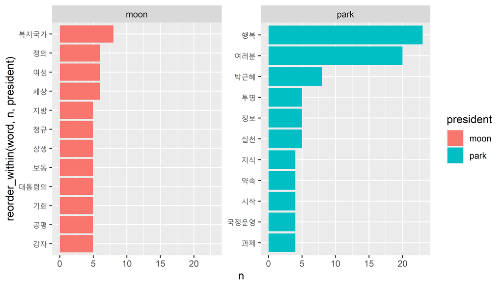

```r
ggplot(top10, aes(x = reorder_within(word, n, president),
                  y = n,
                  fill = president)) +
  geom_col() +
  coord_flip() +
  facet_wrap(~ president, scales = "free_y") +
  scale_x_reordered()
```

- 전반적으로 “park”의 단어 빈도가 높아보임
- `"park"`의 `"행복"` 빈도 기준으로 두 그래프의 x축 크기를 똑같이 고정했기 때문

##### 3. 그래프별로 축 설정하기

- 범주별로 단어 비중 알 수 있도록 x축 크기 각각 정하기

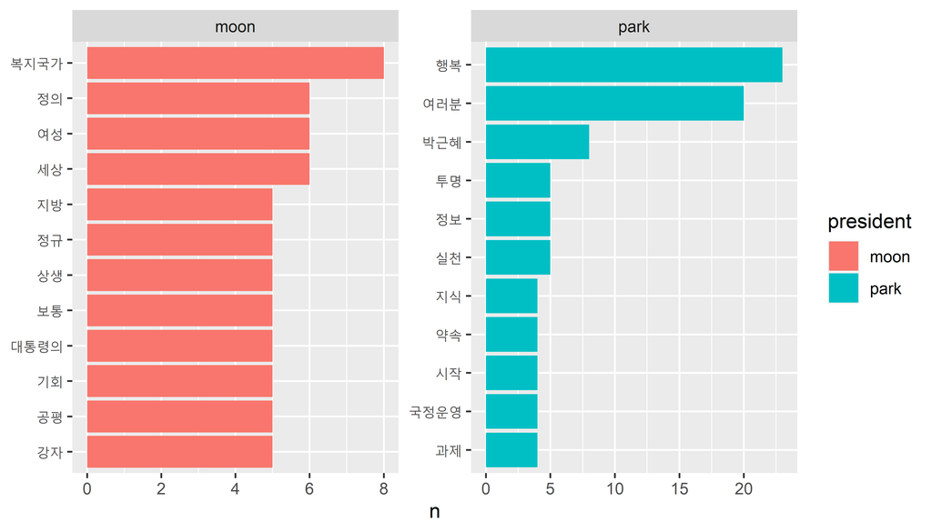

```r
ggplot(top10, aes(x = reorder_within(word, n, president),
                  y = n,
                  fill = president)) +
  geom_col() +
  coord_flip() +
  facet_wrap(~ president, scales = "free") + #<<
  scale_x_reordered() +
  labs(x = NULL) +                                    # x축 삭제
  theme(text = element_text(family = "nanumgothic"))  # 폰트
```

**x축 크기가 그래프마다 다르므로 해석 조심**

- 막대 길이 같아도 단어 빈도 다름
- 두 텍스트 단어 빈도 비교 X
- 각 텍스트에서 상대적으로 중요한 단어가 무엇인지 중심으로 해석

#### 주요 단어가 사용된 문장 살펴보기

##### 1. 원문을 문장 기준으로 토큰화하기

```r
speeches_sentence <- bind_speeches %>%
  as_tibble() %>%
  unnest_tokens(input = value,
                output = sentence,
                token = "sentences")

speeches_sentence
```

```
## # A tibble: 329 x 2
##   president sentence
##   <chr>     <chr>
## 1 moon      "정권교체 하겠습니다!"
## 2 moon      "정치교체 하겠습니다!"
## 3 moon      "시대교체 하겠습니다!"
## 4 moon      ""
## 5 moon      "‘불비불명(不飛不鳴)’이라는 고사가 있습니다."
## 6 moon      "남쪽 언덕 나뭇가지에 앉아, 3년 동안 날지도 울지도 않는 새."
## 7 moon      "그러나 그 새는 한번 날면 하늘 끝까지 날고, 한번 울면 천지를 뒤흔듭~
## 8 moon      "그 동안 정치와 거리를 둬 왔습니다."
## # ... with 321 more rows
```

```r
head(speeches_sentence)
```

```
## # A tibble: 6 x 2
##   president sentence
##   <chr>     <chr>
## 1 moon      "정권교체 하겠습니다!"
## 2 moon      "정치교체 하겠습니다!"
## 3 moon      "시대교체 하겠습니다!"
## 4 moon      ""
## 5 moon      "‘불비불명(不飛不鳴)’이라는 고사가 있습니다."
## 6 moon      "남쪽 언덕 나뭇가지에 앉아, 3년 동안 날지도 울지도 않는 새."
```

```r
tail(speeches_sentence)
```

```
## # A tibble: 6 x 2
##   president sentence
##   <chr>     <chr>
## 1 park      국민 여러분의 행복이 곧 저의 행복입니다.
## 2 park      사랑하는 조국 대한민국과 국민 여러분을 위해, 앞으로 머나 먼 길, 끝~
## 3 park      그 길을 함께 해주시길 부탁드립니다.
## 4 park      감사합니다.
## 5 park      2012년 7월 10일
## 6 park      새누리당 예비후보 박근혜
```

#### 2. 주요 단어가 사용된 문장 추출하기 - `str_detect()`

```r
speeches_sentence %>%
  filter(president == "moon" & str_detect(sentence, "복지국가"))
```

```
## # A tibble: 8 x 2
##   president sentence
##   <chr>     <chr>
## 1 moon      ‘강한 복지국가’를 향해 담대하게 나아가겠습니다.
## 2 moon      2백 년 전 이와 같은 소득재분배, 복지국가의 사상을 가진 위정자가 지~
## 3 moon      이제 우리는 복지국가를 향해 담대하게 나아갈 때입니다.
## 4 moon      부자감세, 4대강 사업 같은 시대착오적 과오를 청산하고, 하루빨리 복지~
## 5 moon      우리는 지금 복지국가로 가느냐, 양극화의 분열된 국가로 가느냐 하는 ~
## 6 moon      강한 복지국가일수록 국가 경쟁력도 더 높습니다.
## 7 moon      결국 복지국가로 가는 길은 사람에 대한 투자, 일자리 창출, 자영업 고~
## 8 moon      우리는 과감히 강한 보편적 복지국가로 가야 합니다.
```

#### 2. 주요 단어가 사용된 문장 추출하기 - `str_detect()`

```r
speeches_sentence %>%
  filter(president == "park" & str_detect(sentence, "행복"))
```

```
## # A tibble: 19 x 2
##    president sentence
##    <chr>     <chr>
##  1 park      저는 오늘, 국민 한 분 한 분의 꿈이 이루어지는 행복한 대한민국을 만~
##  2 park      국가는 발전했고, 경제는 성장했다는데, 나의 삶은 나아지지 않았고, ~
##  3 park      과거에는 국가의 발전이 국민의 행복으로 이어졌습니다.
##  4 park      개인의 창의력이 중요한 지식기반사회에서는 국민 한 사람, 한 사람이 ~
##  5 park      이제 국정운영의 패러다임을 국가에서 국민으로, 개인의 삶과 행복 중~
##  6 park      국민 개개인의 꿈을 향한 노력이 국가를 발전시키고 국가 발전이 국민 ~
##  7 park      저는 ‘경제민주화 실현’, ‘일자리 창출’, 그리고 ‘한국형 복지의 ~
##  8 park      국민행복의 길을 열어갈 첫 번째 과제로, 저는 경제민주화를 통해 중소~
##  9 park      국민행복의 길을 열어갈 두 번째 과제로, 저는 좋은 일자리 창출을 통~
## 10 park      국민행복의 길을 열어갈 세 번째 과제로, 우리의 실정에 맞으면서 국민~
## # ... with 9 more rows
```

#### 중요도가 비슷한 단어 살펴보기

- `odds_ratio`가 1에 가까운 단어 추출
- 대부분 보편적인 의미를 지니는 단어

```r
frequency_wide %>%
  arrange(abs(1 - odds_ratio)) %>%
  head(10)
```

```
## # A tibble: 10 x 6
##    word   moon  park ratio_moon ratio_park odds_ratio
##    <chr> <int> <int>      <dbl>      <dbl>      <dbl>
##  1 강화      4     3    0.00215    0.00220      0.980
##  2 부담      3     2    0.00172    0.00165      1.04
##  3 세계      3     2    0.00172    0.00165      1.04
##  4 책임      3     2    0.00172    0.00165      1.04
##  5 지원      5     4    0.00258    0.00274      0.940
##  6 가슴      2     1    0.00129    0.00110      1.18
##  7 거대      2     1    0.00129    0.00110      1.18
##  8 교체      2     1    0.00129    0.00110      1.18
##  9 기반      2     1    0.00129    0.00110      1.18
## 10 노후      2     1    0.00129    0.00110      1.18
```

#### 중요도가 비슷한 단어 살펴보기

- 중요도가 비슷하면서 빈도가 높은 단어: 두 텍스트에서 모두 강조한 단어

```r
frequency_wide %>%
  filter(moon >= 5 & park >= 5) %>%
  arrange(abs(1 - odds_ratio)) %>%
  head(10)
```

```
## # A tibble: 10 x 6
##    word   moon  park ratio_moon ratio_park odds_ratio
##    <chr> <int> <int>      <dbl>      <dbl>      <dbl>
##  1 산업      8     5    0.00387    0.00329      1.18
##  2 경제     15    15    0.00688    0.00878      0.784
##  3 사람      9     9    0.00430    0.00549      0.784
##  4 사회     15     9    0.00688    0.00549      1.25
##  5 우리     17    10    0.00774    0.00604      1.28
##  6 교육      6     7    0.00301    0.00439      0.686
##  7 불안      6     7    0.00301    0.00439      0.686
##  8 대한     11     6    0.00516    0.00384      1.34
##  9 민국     11     6    0.00516    0.00384      1.34
## 10 국가      7    10    0.00344    0.00604      0.570
```

##### 로그 오즈비(log odds ratio)

- 오즈비에 로그를 취한 값
- 단어의 오즈비가 1보다 크면 `+`, 1보다 작으면 `-`가 됨
- 단어가 두 텍스트 중 어디에서 비중이 큰지에 따라 서로 다른 부호
  - `"moon"`에서 비중이 커서 `odds_ratio`가 1보다 큰 단어 `+`
  - `"park"`에서 비중이 커서 `odds_ratio`가 1보다 작은 단어 `-`

[figure not shown]

$${\large\text{odds ratio} = \frac{\left(\frac{n+1}{\text{total}+1}\right)_\text{Text A}}
{\left(\frac{n+1}{\text{total}+1}\right)_\text{Text B}}}$$

- 텍스트 차이 분명하게 드러나도록 시각화하는데 활용
- 단어가 어느 텍스트에서 중요한지에 따라 막대를 반대 방향으로 표현

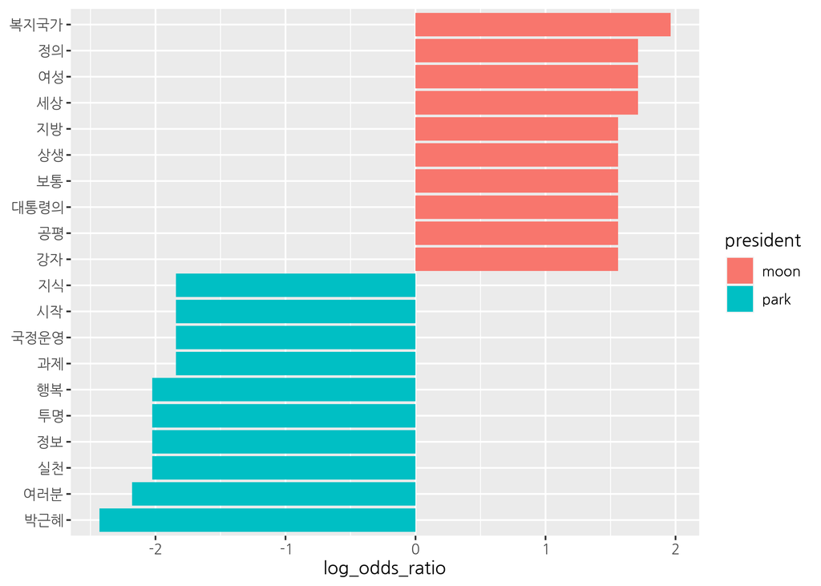

#### 로그 오즈비 구하기

```r
frequency_wide <- frequency_wide %>%
  mutate(log_odds_ratio = log(odds_ratio))

frequency_wide
```

```
## # A tibble: 966 x 7
##    word      moon  park ratio_moon ratio_park odds_ratio log_odds_ratio
##    <chr>    <int> <int>      <dbl>      <dbl>      <dbl>          <dbl>
##  1 가능성       1     0   0.000860   0.000549      1.57           0.449
##  2 가동         1     0   0.000860   0.000549      1.57           0.449
##  3 가사         1     0   0.000860   0.000549      1.57           0.449
##  4 가슴         2     1   0.00129    0.00110       1.18           0.162
##  5 가족         1     1   0.000860   0.00110       0.784         -0.244
##  6 가족구조     1     0   0.000860   0.000549      1.57           0.449
##  7 가지         4     0   0.00215    0.000549      3.92           1.37
##  8 가치         3     1   0.00172    0.00110       1.57           0.449
##  9 각종         1     0   0.000860   0.000549      1.57           0.449
## 10 감당         1     0   0.000860   0.000549      1.57           0.449
## # ... with 956 more rows
```

- **부호**와 **크기**를 보면 단어가 어느 연설문에서 더 중요한지 알 수 있음
  - **0보다 큰 양수일수록 `"moon`“에서 비중이 큼**
  - 0보다 작은 음수일수록 `"park"`에서 비중이 큼
  - 0에 가까우면 두 연설문에서 비중 비슷함

```r
# moon에서 비중이 큰 단어
frequency_wide %>%
  arrange(-log_odds_ratio) #<<
```

```
## # A tibble: 966 x 7
##    word      moon  park ratio_moon ratio_park odds_ratio log_odds_ratio
##    <chr>    <int> <int>      <dbl>      <dbl>      <dbl>          <dbl>
##  1 복지국가     8     0    0.00387   0.000549       7.05           1.95
##  2 세상         6     0    0.00301   0.000549       5.49           1.70
##  3 여성         6     0    0.00301   0.000549       5.49           1.70
##  4 정의         6     0    0.00301   0.000549       5.49           1.70
##  5 강자         5     0    0.00258   0.000549       4.70           1.55
##  6 공평         5     0    0.00258   0.000549       4.70           1.55
##  7 기회         5     0    0.00258   0.000549       4.70           1.55
##  8 대통령의     5     0    0.00258   0.000549       4.70           1.55
##  9 보통         5     0    0.00258   0.000549       4.70           1.55
## 10 상생         5     0    0.00258   0.000549       4.70           1.55
## # ... with 956 more rows
```

- 부호와 크기를 보면 단어가 어느 연설문에서 더 중요한지 알 수 있음
  - 0보다 큰 양수일수록 `"moon`“에서 비중이 큼
  - **0보다 작은 음수일수록 `"park"`에서 비중이 큼**
  - 0에 가까우면 두 연설문에서 비중 비슷함

```r
# park에서 비중이 큰 단어
frequency_wide %>%
  arrange(log_odds_ratio) #<<
```

```
## # A tibble: 966 x 7
##    word      moon  park ratio_moon ratio_park odds_ratio log_odds_ratio
##    <chr>    <int> <int>      <dbl>      <dbl>      <dbl>          <dbl>
##  1 박근혜       0     8   0.000430    0.00494     0.0871          -2.44
##  2 여러분       2    20   0.00129     0.0115      0.112           -2.19
##  3 행복         3    23   0.00172     0.0132      0.131           -2.04
##  4 실천         0     5   0.000430    0.00329     0.131           -2.04
##  5 정보         0     5   0.000430    0.00329     0.131           -2.04
##  6 투명         0     5   0.000430    0.00329     0.131           -2.04
##  7 과제         0     4   0.000430    0.00274     0.157           -1.85
##  8 국정운영     0     4   0.000430    0.00274     0.157           -1.85
##  9 시작         0     4   0.000430    0.00274     0.157           -1.85
## 10 약속         0     4   0.000430    0.00274     0.157           -1.85
## # ... with 956 more rows
```

- 부호와 크기를 보면 단어가 어느 연설문에서 더 중요한지 알 수 있음
  - 0보다 큰 양수일수록 `"moon`“에서 비중이 큼
  - 0보다 작은 음수일수록 `"park"`에서 비중이 큼
  - **0에 가까우면 두 연설문에서 비중 비슷함**

```r
# 비중이 비슷한 단어
frequency_wide %>%
  arrange(abs(log_odds_ratio)) #<<
```

```
## # A tibble: 966 x 7
##    word   moon  park ratio_moon ratio_park odds_ratio log_odds_ratio
##    <chr> <int> <int>      <dbl>      <dbl>      <dbl>          <dbl>
##  1 강화      4     3    0.00215    0.00220      0.980        -0.0206
##  2 부담      3     2    0.00172    0.00165      1.04          0.0439
##  3 세계      3     2    0.00172    0.00165      1.04          0.0439
##  4 책임      3     2    0.00172    0.00165      1.04          0.0439
##  5 지원      5     4    0.00258    0.00274      0.940        -0.0615
##  6 가슴      2     1    0.00129    0.00110      1.18          0.162
##  7 거대      2     1    0.00129    0.00110      1.18          0.162
##  8 교체      2     1    0.00129    0.00110      1.18          0.162
##  9 기반      2     1    0.00129    0.00110      1.18          0.162
## 10 노후      2     1    0.00129    0.00110      1.18          0.162
## # ... with 956 more rows
```

#### 로그 오즈비 간단히 구하기

```r
frequency_wide <- frequency_wide %>%
  mutate(log_odds_ratio = log(((moon + 1) / (sum(moon + 1))) /
                              ((park + 1) / (sum(park + 1)))))
```

#### 로그 오즈비를 이용해 중요한 단어 비교하기

- 두 연설문 각각 `log_odds_ratio` Top 10 추출

```r
top10 <- frequency_wide %>%
  group_by(president = ifelse(log_odds_ratio > 0, "moon", "park")) %>%
  slice_max(abs(log_odds_ratio), n = 10, with_ties = F)

top10
```

```
## # A tibble: 20 x 8
## # Groups:   president [2]
##    word      moon  park ratio_moon ratio_park odds_ratio log_odds_ratio president
##    <chr>    <int> <int>      <dbl>      <dbl>      <dbl>          <dbl> <chr>
##  1 복지국가     8     0   0.00387    0.000549     7.05             1.95 moon
##  2 세상         6     0   0.00301    0.000549     5.49             1.70 moon
##  3 여성         6     0   0.00301    0.000549     5.49             1.70 moon
##  4 정의         6     0   0.00301    0.000549     5.49             1.70 moon
##  5 강자         5     0   0.00258    0.000549     4.70             1.55 moon
##  6 공평         5     0   0.00258    0.000549     4.70             1.55 moon
##  7 기회         5     0   0.00258    0.000549     4.70             1.55 moon
##  8 대통령의     5     0   0.00258    0.000549     4.70             1.55 moon
##  9 보통         5     0   0.00258    0.000549     4.70             1.55 moon
## 10 상생         5     0   0.00258    0.000549     4.70             1.55 moon
## 11 박근혜       0     8   0.000430   0.00494      0.0871          -2.44 park
## 12 여러분       2    20   0.00129    0.0115       0.112           -2.19 park
## 13 행복         3    23   0.00172    0.0132       0.131           -2.04 park
## 14 실천         0     5   0.000430   0.00329      0.131           -2.04 park
## 15 정보         0     5   0.000430   0.00329      0.131           -2.04 park
## 16 투명         0     5   0.000430   0.00329      0.131           -2.04 park
## 17 과제         0     4   0.000430   0.00274      0.157           -1.85 park
## 18 국정운영     0     4   0.000430   0.00274      0.157           -1.85 park
## 19 시작         0     4   0.000430   0.00274      0.157           -1.85 park
## 20 약속         0     4   0.000430   0.00274      0.157           -1.85 park
```

##### 주요 변수 추출

```r
top10 %>%
  arrange(-log_odds_ratio) %>%
  select(word, log_odds_ratio, president)
```

```
## # A tibble: 20 x 3
## # Groups:   president [2]
##    word     log_odds_ratio president
##    <chr>             <dbl> <chr>
##  1 복지국가           1.95 moon
##  2 세상               1.70 moon
##  3 여성               1.70 moon
##  4 정의               1.70 moon
##  5 강자               1.55 moon
##  6 공평               1.55 moon
##  7 기회               1.55 moon
##  8 대통령의           1.55 moon
##  9 보통               1.55 moon
## 10 상생               1.55 moon
## # ... with 10 more rows
```

```
## # A tibble: 20 x 3
## # Groups:   president [2]
##    word     log_odds_ratio president
##    <chr>             <dbl> <chr>
##  1 복지국가           1.95 moon
##  2 세상               1.70 moon
##  3 여성               1.70 moon
##  4 정의               1.70 moon
##  5 강자               1.55 moon
##  6 공평               1.55 moon
##  7 기회               1.55 moon
##  8 대통령의           1.55 moon
##  9 보통               1.55 moon
## 10 상생               1.55 moon
## 11 과제              -1.85 park
## 12 국정운영          -1.85 park
## 13 시작              -1.85 park
## 14 약속              -1.85 park
## 15 행복              -2.04 park
## 16 실천              -2.04 park
## 17 정보              -2.04 park
## 18 투명              -2.04 park
## 19 여러분            -2.19 park
## 20 박근혜            -2.44 park
```

[output not shown]

**오즈비 기준 상·하위 10개 추출했을 때와 단어 동일**

```r
frequency_wide %>%
  filter(rank(odds_ratio) <= 10 | rank(-odds_ratio) <= 10) %>%
  arrange(-odds_ratio)
```

#### 막대 그래프 만들기

- 단어가 어느 연설문에서 중요한지에 따라 서로 다른 축 방향으로 표현됨

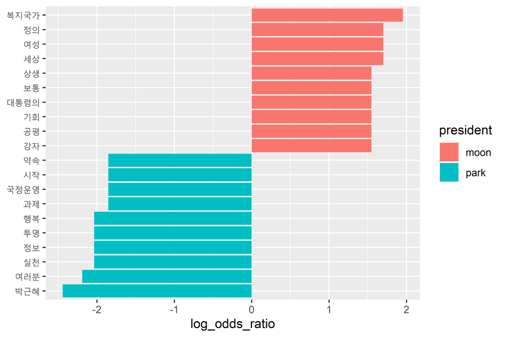

##### 오즈비의 한계

- 두 조건의 확률을 이용해 계산
- 여러 텍스트 비교하기 불편
- 두 개 이상의 텍스트 비교할 때는 **TF-IDF** 활용

–

##### 중요한 단어?

- 흔하지 않으면서도 특정 텍스트에서는 자주 사용된 단어
- 텍스트가 다른 텍스트와 구별되는 특징, 개성을 드러내는 단어
  - ex) 자기소개서: “저는” vs “스카이다이빙”

#### TF-IDF(Term Frequency - Inverse Document Frequency)

- 어떤 단어가 흔하지 않으면서도 특정 텍스트에서는 자주 사용된 정도를 나타낸 지표
- 텍스트의 개성을 드러내는 주요 단어를 찾는데 활용

–

##### TF(Term Frequency)

- 단어가 특정 텍스트에 사용된 횟수 - 단어 빈도

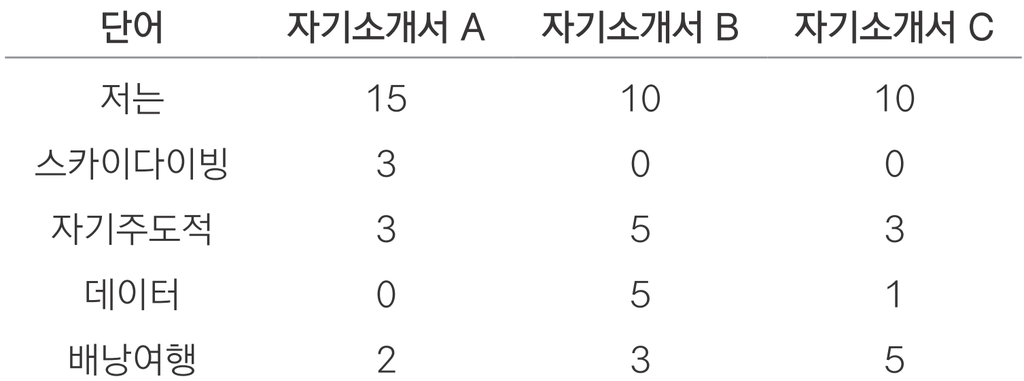

##### DF와 IDF

- **DF(Document Frequency)**
  - 단어가 사용된 텍스트 수 - ‘문서 빈도’
  - 클수록 여러 문서에 흔하게 사용된 일반적인 단어
- **IDF(Inverse Document Frequency)**
  - ‘역문서 빈도’
    - 1. 전체 문서 수(N)에서 DF가 차지하는 비중을 구함
    - 2. 그 값의 역수를 취함
    - 3. 로그를 취함
  - DF가 클수록 작아지고, 반대로 DF가 작을수록 커짐
  - 클수록 드물게 사용되는 특이한 단어, 작을수록 흔하게 사용되는 일반적인 단어

$${\large\text{IDF} = \log{\frac{{\text{N}}}{{\text{DF}}}}}$$

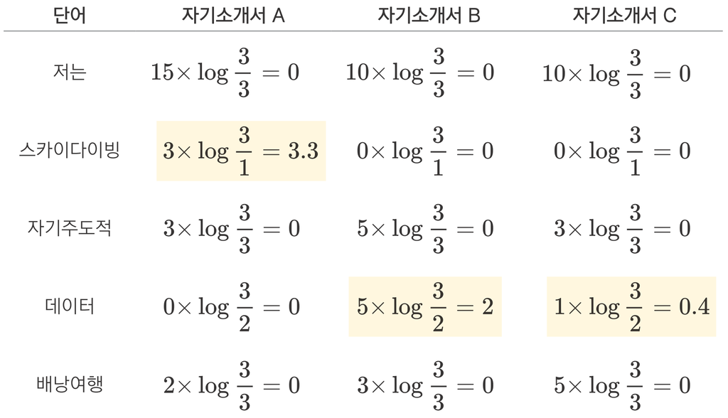

#### TF-IDF 구하기

##### 1. 단어 빈도 구하기

- `speeches_presidents.csv` : 역대 대통령의 대선 출마 선언문
- `readr::read_csv()` 데이터를 다루기 편한 tibble 구조로 만들어 줌, `read.csv()`보다 빠름

```r
# 데이터 불러오기
install.packages("readr")
library(readr)

raw_speeches <- read_csv("speeches_presidents.csv")
raw_speeches
```

```
## # A tibble: 4 x 2
##   president value
##   <chr>     <chr>
## 1 문재인    "정권교체 하겠습니다!   정치교체 하겠~
## 2 박근혜    "존경하는 국민 여러분! 저는 오늘, 국~
## 3 이명박    "존경하는 국민 여러분, 사랑하는 한나~
## 4 노무현    "어느때인가 부터 제가 대통령이 되겠다~
```

```r
# 기본적인 전처리
speeches <- raw_speeches %>%
  mutate(value = str_replace_all(value, "[^가-힣]", " "),
         value = str_squish(value))

# 토큰화
speeches <- speeches %>%
  unnest_tokens(input = value,
                output = word,
                token = extractNoun)

# 단어 빈도 구하기
frequecy <- speeches %>%
  count(president, word) %>%
  filter(str_count(word) > 1)

frequecy
```

```
## # A tibble: 1,515 x 3
##    president word      n
##    <chr>     <chr> <int>
##  1 노무현    가슴      2
##  2 노무현    가훈      2
##  3 노무현    감옥      1
##  4 노무현    강자      1
##  5 노무현    개편      4
##  6 노무현    개혁      5
##  7 노무현    건국      1
##  8 노무현    경선      1
##  9 노무현    경쟁      1
## 10 노무현    경제      1
## # ... with 1,505 more rows
```

#### 3.4.2 TF-IDF 구하기

- `tidytext::bind_tf_idf()`
  - `term` : 단어
  - `document` : 텍스트 구분 기준
  - `n` : 단어 빈도

```r
frequecy <- frequecy %>%
  bind_tf_idf(term = word,           # 단어
              document = president,  # 텍스트 구분 기준
              n = n) %>%             # 단어 빈도
  arrange(-tf_idf)

frequecy
```

```
## # A tibble: 1,515 x 6
##    president word         n     tf   idf tf_idf
##    <chr>     <chr>    <int>  <dbl> <dbl>  <dbl>
##  1 노무현    공식         6 0.0165 1.39  0.0229
##  2 노무현    비젼         6 0.0165 1.39  0.0229
##  3 노무현    정계         6 0.0165 1.39  0.0229
##  4 이명박    리더십       6 0.0154 1.39  0.0214
##  5 이명박    한나라당     5 0.0129 1.39  0.0178
##  6 노무현    권력         9 0.0247 0.693 0.0171
##  7 노무현    개편         4 0.0110 1.39  0.0152
##  8 이명박    당원         4 0.0103 1.39  0.0143
##  9 이명박    동지         4 0.0103 1.39  0.0143
## 10 이명박    일류국가     4 0.0103 1.39  0.0143
## # ... with 1,505 more rows
```

##### TF-IDF가 높은 단어 살펴보기

- 텍스트의 특징을 드러내는 중요한 단어
- 각 대통령이 다른 대통령들과 달리 무엇을 강조했는지 알 수 있음

```r
frequecy %>% filter(president == "문재인")
```

```
## # A tibble: 692 x 6
##    president word         n      tf   idf  tf_idf
##    <chr>     <chr>    <int>   <dbl> <dbl>   <dbl>
##  1 문재인    복지국가     8 0.00606 1.39  0.00840
##  2 문재인    여성         6 0.00455 1.39  0.00630
##  3 문재인    확대        11 0.00833 0.693 0.00578
##  4 문재인    공평         5 0.00379 1.39  0.00525
##  5 문재인    대통령의     5 0.00379 1.39  0.00525
##  6 문재인    보통         5 0.00379 1.39  0.00525
##  7 문재인    상생         5 0.00379 1.39  0.00525
##  8 문재인    우리나라    10 0.00758 0.693 0.00525
##  9 문재인    정규         5 0.00379 1.39  0.00525
## 10 문재인    지방         5 0.00379 1.39  0.00525
## # ... with 682 more rows
```

```r
frequecy %>% filter(president == "박근혜")
```

```
## # A tibble: 400 x 6
##    president word         n      tf   idf  tf_idf
##    <chr>     <chr>    <int>   <dbl> <dbl>   <dbl>
##  1 박근혜    박근혜       8 0.00973 1.39  0.0135
##  2 박근혜    정보         5 0.00608 1.39  0.00843
##  3 박근혜    투명         5 0.00608 1.39  0.00843
##  4 박근혜    행복        23 0.0280  0.288 0.00805
##  5 박근혜    국정운영     4 0.00487 1.39  0.00675
##  6 박근혜    정부        17 0.0207  0.288 0.00595
##  7 박근혜    교육         7 0.00852 0.693 0.00590
##  8 박근혜    개개인       3 0.00365 1.39  0.00506
##  9 박근혜    개인         3 0.00365 1.39  0.00506
## 10 박근혜    공개         3 0.00365 1.39  0.00506
## # ... with 390 more rows
```

```r
frequecy %>% filter(president == "이명박")
```

```
## # A tibble: 203 x 6
##    president word         n      tf   idf  tf_idf
##    <chr>     <chr>    <int>   <dbl> <dbl>   <dbl>
##  1 이명박    리더십       6 0.0154  1.39  0.0214
##  2 이명박    한나라당     5 0.0129  1.39  0.0178
##  3 이명박    당원         4 0.0103  1.39  0.0143
##  4 이명박    동지         4 0.0103  1.39  0.0143
##  5 이명박    일류국가     4 0.0103  1.39  0.0143
##  6 이명박    나라        15 0.0386  0.288 0.0111
##  7 이명박    도약         3 0.00771 1.39  0.0107
##  8 이명박    사랑         5 0.0129  0.693 0.00891
##  9 이명박    인생         5 0.0129  0.693 0.00891
## 10 이명박    대한        12 0.0308  0.288 0.00887
## # ... with 193 more rows
```

```r
frequecy %>% filter(president == "노무현")
```

```
## # A tibble: 220 x 6
##    president word         n      tf   idf  tf_idf
##    <chr>     <chr>    <int>   <dbl> <dbl>   <dbl>
##  1 노무현    공식         6 0.0165  1.39  0.0229
##  2 노무현    비젼         6 0.0165  1.39  0.0229
##  3 노무현    정계         6 0.0165  1.39  0.0229
##  4 노무현    권력         9 0.0247  0.693 0.0171
##  5 노무현    개편         4 0.0110  1.39  0.0152
##  6 노무현    구도         3 0.00824 1.39  0.0114
##  7 노무현    국회의원     3 0.00824 1.39  0.0114
##  8 노무현    남북대화     3 0.00824 1.39  0.0114
##  9 노무현    총리         3 0.00824 1.39  0.0114
## 10 노무현    개혁         5 0.0137  0.693 0.00952
## # ... with 210 more rows
```

##### TF-IDF가 낮은 단어 살펴보기

- 역대 대통령들이 공통적으로 사용한 흔한 단어, 범용 단어

```r
frequecy %>%
  filter(president == "문재인") %>%
  arrange(tf_idf)
```

```
## # A tibble: 692 x 6
##    president word       n       tf   idf tf_idf
##    <chr>     <chr>  <int>    <dbl> <dbl>  <dbl>
##  1 문재인    경쟁       6 0.00455      0      0
##  2 문재인    경제      15 0.0114       0      0
##  3 문재인    고통       4 0.00303      0      0
##  4 문재인    과거       1 0.000758     0      0
##  5 문재인    국민      21 0.0159       0      0
##  6 문재인    대통령    12 0.00909      0      0
##  7 문재인    동안       2 0.00152      0      0
##  8 문재인    들이      10 0.00758      0      0
##  9 문재인    마음       2 0.00152      0      0
## 10 문재인    무엇       1 0.000758     0      0
## # ... with 682 more rows
```

```r
frequecy %>%
  filter(president == "박근혜") %>%
  arrange(tf_idf)
```

```
## # A tibble: 400 x 6
##    president word       n      tf   idf tf_idf
##    <chr>     <chr>  <int>   <dbl> <dbl>  <dbl>
##  1 박근혜    경쟁       1 0.00122     0      0
##  2 박근혜    경제      15 0.0182      0      0
##  3 박근혜    고통       4 0.00487     0      0
##  4 박근혜    과거       2 0.00243     0      0
##  5 박근혜    국민      71 0.0864      0      0
##  6 박근혜    대통령     3 0.00365     0      0
##  7 박근혜    동안       3 0.00365     0      0
##  8 박근혜    들이       4 0.00487     0      0
##  9 박근혜    마음       3 0.00365     0      0
## 10 박근혜    무엇       2 0.00243     0      0
## # ... with 390 more rows
```

#### 막대 그래프 만들기

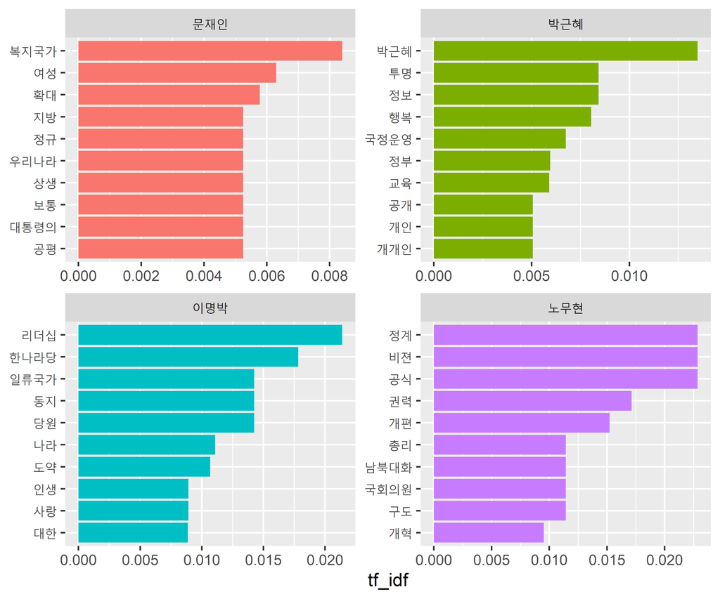

```r
# 주요 단어 추출
top10 <- frequecy %>%
  group_by(president) %>%
  slice_max(tf_idf, n = 10, with_ties = F)

# 그래프 순서 정하기
top10$president <- factor(top10$president,
                          levels = c("문재인", "박근혜", "이명박", "노무현"))

# 막대 그래프 만들기
ggplot(top10, aes(x = reorder_within(word, tf_idf, president),
                  y = tf_idf,
                  fill = president)) +
  geom_col(show.legend = F) +
  coord_flip() +
  facet_wrap(~ president, scales = "free", ncol = 2) +
  scale_x_reordered() +
  labs(x = NULL) +
  theme(text = element_text(family = "nanumgothic"))
```

### 정리하기

##### 1. 단어 빈도 비교하기

```r
# 토큰화
speeches <- speeches %>%
  unnest_tokens(input = value,
                output = word,
                token = extractNoun)

# 하위 집단별 단어 빈도 구하기
frequency <- speeches %>%
  count(president, word) %>%
  filter(str_count(word) > 1)

# 가장 많이 사용된 단어 추출
top10 <- frequency %>%
  group_by(president) %>%
  slice_max(n, n = 10, with_ties = F)
```

### 정리하기

##### 2. 로그 오즈비로 단어 비교하기

```r
# long form을 wide form으로 변환
frequency_wide <- frequency %>%
  pivot_wider(names_from = president,
              values_from = n,
              values_fill = list(n = 0))

# 로그 오즈비 구하기
frequency_wide <- frequency_wide %>%
  mutate(log_odds_ratio = log(((moon + 1) / (sum(moon + 1))) /
                              ((park + 1) / (sum(park + 1)))))

# 상대적으로 중요한 단어 추출
top10 <- frequency_wide %>%
  group_by(president = ifelse(log_odds_ratio > 0, "moon", "park")) %>%
  slice_max(abs(log_odds_ratio), n = 10, with_ties = F)
```

### 정리하기

##### 3. TF-IDF로 단어 비교하기

```r
# TF-IDF 구하기
frequecy <- frequecy %>%
  bind_tf_idf(term = word,
              document = president,
              n = n) %>%
  arrange(-tf_idf)

# 상대적으로 중요한 단어 추출
top10 <- frequecy %>%
  arrange(tf_idf) %>%
  group_by(president) %>%
  slice_max(tf_idf, n = 10, with_ties = F)
```